# individual1

Christopher Spartz

9/30/2021

## R Markdown

```r
library(ggplot2)
library(tidyverse)
dat <- readxl::read_xls('GSS.xls')
dat <- dat %>% rename(year="Gss year for this respondent",
         rid="Respondent id number",
         hours_week="Number of hours usually work a week",
         marital="Marital status",
         school="Highest year of school completed",
         rsex="Respondents sex",
         pol_party="Political party affiliation",
         happy="General happiness",
         ballot="Ballot used for interview")
```

Data Cleanup

```r
cols.num <- c("hours_week","school")
dat[cols.num] <- sapply(dat[cols.num],as.numeric)
dat[dat=="No answer" | dat=="Don't know"] <- NA
dat[dat=="Not applicable"] <- NA
```

## 1.

```r
medu <- dat %>% group_by(marital) %>% na.omit %>% summarise(education = mean(school, na.rm=TRUE)) %>% arrange(desc(education))
medu
```

```
## # A tibble: 5 × 2
##   marital       education
##   <chr>             <dbl>
## 1 Married            14.2
## 2 Never married      13.8
## 3 Separated          13.6
## 4 Divorced           13.4
## 5 Widowed            12.6
```

## 2.

```r
#by_mar <- dat %>% group_by(marital)
#by_mar <- by_mar %>% filter(school>=mean(school))
by_mar <- dat %>%
  group_by(marital) %>%
  filter(school > mean(school, na.rm = TRUE)) %>%
  ungroup()
str(by_mar)
```

```
## tibble [30,714 × 9] (S3: tbl_df/tbl/data.frame)
##  $ year      : num [1:30714] 1972 1972 1972 1972 1972 ...
##  $ rid       : num [1:30714] 1 4 6 8 11 16 17 19 20 23 ...
##  $ hours_week: num [1:30714] NA NA NA NA NA NA NA NA NA NA ...
##  $ marital   : chr [1:30714] "Never married" "Married" "Never married" "Never married" ...
##  $ school    : num [1:30714] 16 17 14 16 13 14 14 17 14 13 ...
##  $ rsex      : chr [1:30714] "Female" "Female" "Male" "Male" ...
##  $ pol_party : chr [1:30714] "Ind,near dem" "Not str democrat" "Ind,near dem" "Ind,near dem" ...
##  $ happy     : chr [1:30714] "Not too happy" "Not too happy" "Pretty happy" "Not too happy" ...
##  $ ballot    : chr [1:30714] NA NA NA NA ...
```

## 3.

```r
happyByMar <- dat %>% group_by(marital) %>% na.omit %>%
  summarise(Happy=sum(happy %in% c("Very happy","Pretty happy")),
  Not_Happy=sum(happy=="Not too happy"))
happyByMar
```

```
## # A tibble: 5 × 3
##   marital       Happy Not_Happy
##   <chr>         <int>     <int>
## 1 Divorced         85        27
## 2 Married         334        30
## 3 Never married   136        36
## 4 Separated        18        12
## 5 Widowed          27         8
```

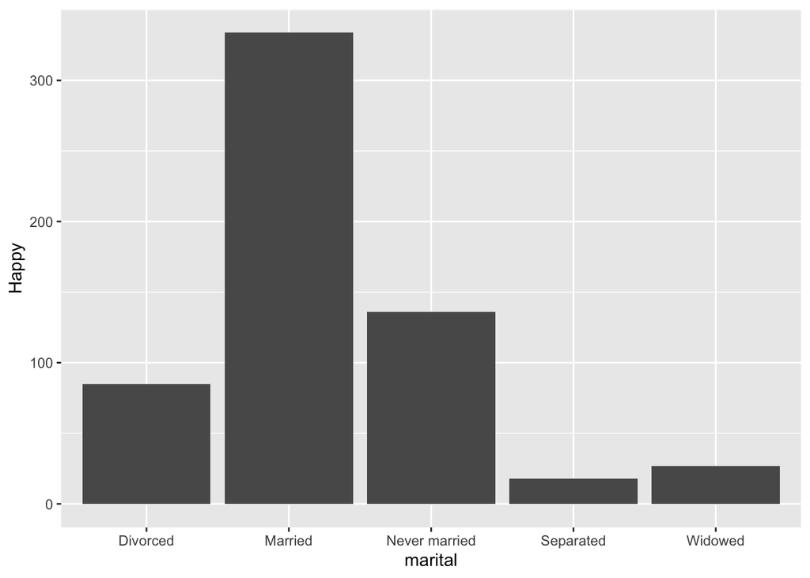

```r
ggplot(happyByMar, aes(x = marital, y = Happy)) +geom_bar(stat = 'identity')
```

Overall most of the people in this data set are happy. On average a person tends to be happier if they are married than if they are single. Never married and divorced and widowed tended to be the most average in terms of happiness, with about three times more people happy vs. unhappy. Separated individuals is where the unhappy people starts to rise, and 40% of the people who answered as separated said that they were unhappy. That is a considerable amount more than the other marital statuses.

## 4.

```r
happyByPol <- dat %>% group_by(pol_party) %>% na.omit %>%
  summarise(Happy=sum(happy %in% c("Very happy","Pretty happy")),
  Not_Happy=sum(happy=="Not too happy"))
happyByPol
```

```
## # A tibble: 8 × 3
##   pol_party          Happy Not_Happy
##   <chr>              <int>     <int>
## 1 Ind,near dem          62        22
## 2 Ind,near rep          50        12
## 3 Independent           96        22
## 4 Not str democrat     108        35
## 5 Not str republican   122         6
## 6 Other party           10         2
## 7 Strong democrat       91        13
## 8 Strong republican     61         1
```

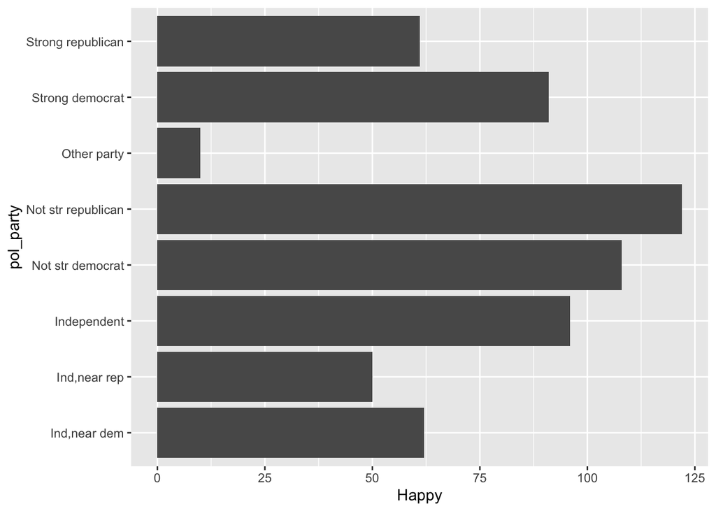

```r
ggplot(happyByPol, aes(x = pol_party, y = Happy)) +geom_bar(stat = 'identity') +
  coord_flip()
```

## 5.

```r
happyByWork <- dat %>% group_by(happy) %>% na.omit %>%
  summarise(Short=sum(hours_week<40),
  Normal=sum(hours_week==40),
  Long=sum(hours_week>40))
happyByWork
```

```
## # A tibble: 3 × 4
##   happy         Short Normal  Long
##   <chr>         <int>  <int> <int>
## 1 Not too happy    39     49    25
## 2 Pretty happy    132    164   107
## 3 Very happy       53     71    73
```

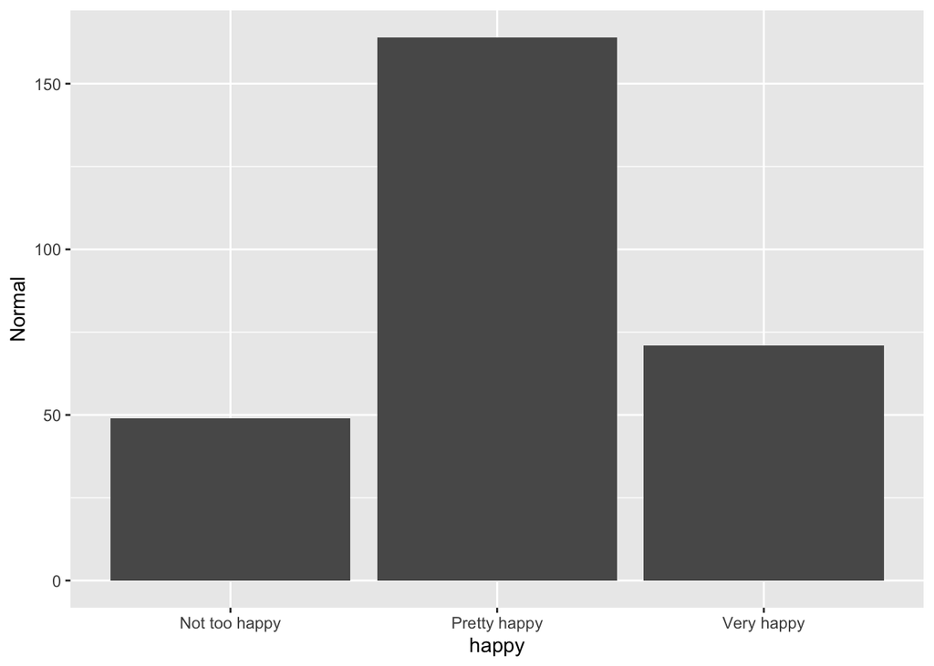

```r
ggplot(happyByWork, aes(x = happy, y = Normal)) +geom_bar(stat = 'identity')
```

Participants who reported working an average hours of 40 a week and those that reported working less than 40 hours a week reported an about equal percentage of happy and unhappy people. Whereas those who reported working more than 40 hours a week were just slightly more happy on average. Surprisingly, the data given here says that hours worked a week and happiness are not very correlated with one another.